# Lab Assignment 2

```python
#Dataset-2 scores
print("Scores for Dataset-2:")
score_list_df2 = [km_score_df2, dbscan_score_df2, em_score_df2, al_score_df2]

#Create the pandas DataFrame
scores_df2 = pd.DataFrame(score_list_df2, columns = ['Silhouette score', 'Normalized mutual info score', 'Algorithm'])

#find max score algorithm's name and append it in last row
best = scores_df2["Algorithm"].iloc[scores_df2['Normalized mutual info score'].idxmax()]
scores_df2.loc[len(scores_df2.index)] = ['Best clustering algorithm', "------->", best]
scores_df2
```

```
Scores for Dataset-2:
```

|  | Silhouette score | Normalized mutual info score | Algorithm |
| --- | --- | --- | --- |
| 0 | 0.545839 | 0.766637 | k-means |
| 1 | 0.032213 | 0.870569 | DBSCAN |
| 2 | 0.570693 | 0.797949 | Expectation maximization |
| 3 | 0.599658 | 0.806069 | Agglomerative Clustering |
| 4 | Best clustering algorithm | -------> | DBSCAN |

```
Dataset-3=========================================================
K-means===========================================================
```

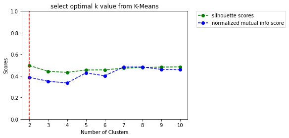

```
Optimal K value for this dataset(K-Means): 2
```

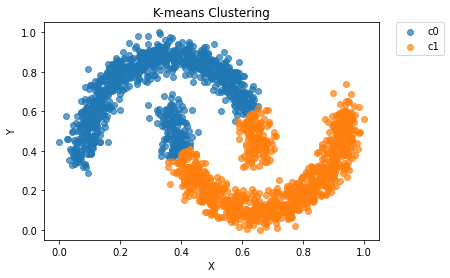

```
DBSCAN==========================================================
```

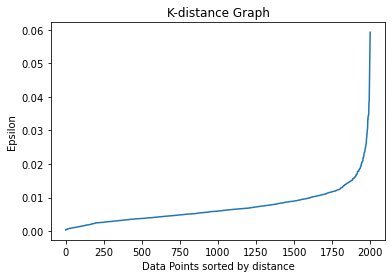

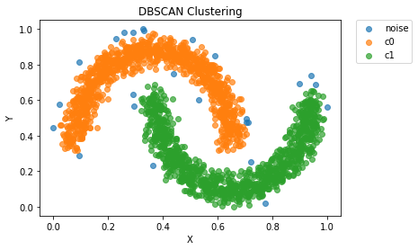

```
Expectation Maximization========================================
```

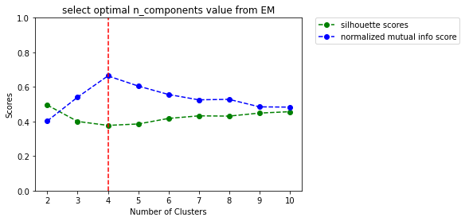

```
Optimal n_components value for this dataset(EM): 4
```

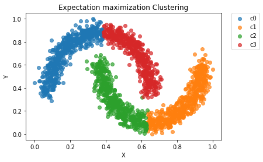

```
Agglomerative Clustering=====================================================
```

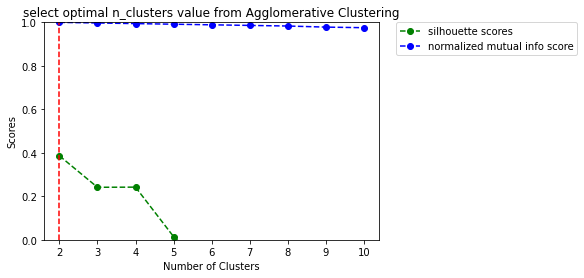

```
Optimal n_clusters value for this dataset(Agglomerative Clustering): 2
```

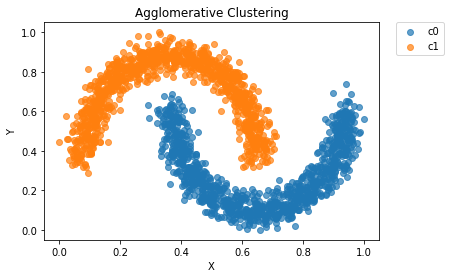

```python
#Dataset-3 ---------------------------------------------------------------------------------------------------------------------
#k-means
print("Dataset-3=========================================================")
print("K-means===========================================================")
km_score_df3 = k_means(df=df3)

#DBSCAN
print("\nDBSCAN==========================================================")
dbscan_score_df3 = db_scan(eps=0.03,
                           min_samples=5,
                           df=df3)

#expectation maximization
print("\nExpectation Maximization========================================")
em_score_df3 = expectation_maximization(covariance_type='full',
                                        n_init=10,
                                        init_params='kmeans',
                                        df=df3)

#AgglomerativeClustering
print("\nAgglomerative Clustering=====================================================")
al_score_df3 = agglomerative_clustering(linkage="single",
                                        df=df3)
```

```python
#Dataset-3 scores
print("Scores for Dataset-3:")
score_list_df3 = [km_score_df3, dbscan_score_df3, em_score_df3, al_score_df3]

#Create the pandas DataFrame
scores_df3 = pd.DataFrame(score_list_df3, columns = ['Silhouette score', 'Normalized mutual info score', 'Algorithm'])

#find max score algorithm's name and append it in last row
best = scores_df3["Algorithm"].iloc[scores_df3['Normalized mutual info score'].idxmax()]
scores_df3.loc[len(scores_df3.index)] = ['Best clustering algorithm', "------->", best]
scores_df3
```

```
Scores for Dataset-3:
```

|  | Silhouette score | Normalized mutual info score | Algorithm |
| --- | --- | --- | --- |
| 0 | 0.495734 | 0.386419 | k-means |
| 1 | 0.285016 | 0.948186 | DBSCAN |
| 2 | 0.3775 | 0.663722 | Expectation maximization |
| 3 | 0.38616 | 1.0 | Agglomerative Clustering |
| 4 | Best clustering algorithm | -------> | Agglomerative Clustering |

```
Dataset-4=========================================================
K-means===========================================================
```

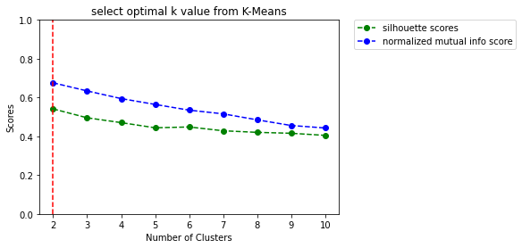

```
Optimal K value for this dataset(K-Means): 2
```

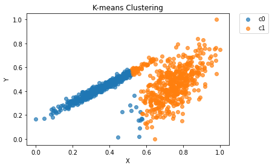

```
DBSCAN==========================================================
```

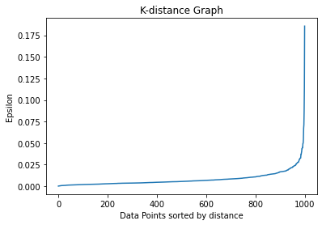

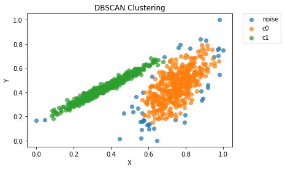

```
Expectation Maximization========================================
```

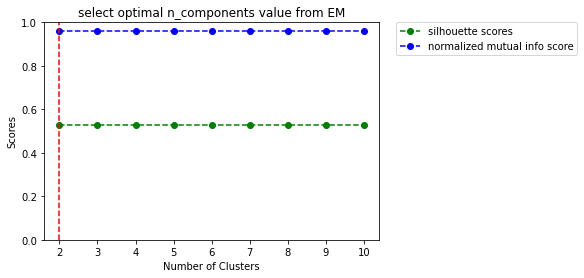

```
Optimal n_components value for this dataset(EM): 2
```

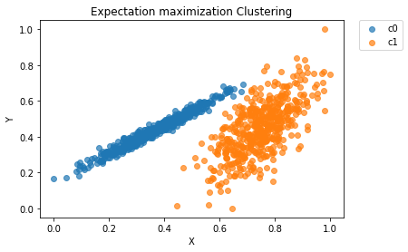

```
Agglomerative Clustering=====================================================
```

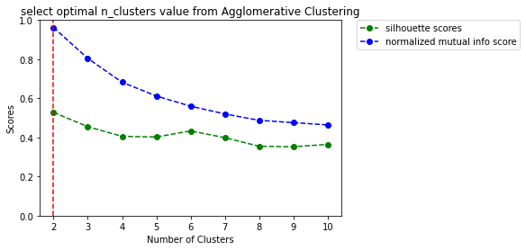

```
Optimal n_clusters value for this dataset(Agglomerative Clustering): 2
```

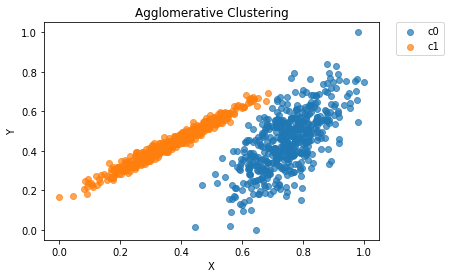

```python
#Dataset-4 ---------------------------------------------------------------------------------------------------------------------
#k-means
print("Dataset-4=========================================================")
print("K-means===========================================================")
km_score_df4 = k_means(df=df4)

#DBSCAN
print("\nDBSCAN==========================================================")
dbscan_score_df4 = db_scan(eps=0.035,
                           min_samples=5,
                           df=df4)

#expectation maximization
print("\nExpectation Maximization========================================")
em_score_df4 = expectation_maximization(covariance_type='full',
                                        n_init=10,
                                        init_params='kmeans',
                                        df=df4)

#AgglomerativeClustering
print("\nAgglomerative Clustering=====================================================")
al_score_df4 = agglomerative_clustering(linkage="ward",
                                        df=df4)
```

```python
#Dataset-4 scores
print("Scores for Dataset-4:")
score_list_df4 = [km_score_df4, dbscan_score_df4, em_score_df4, al_score_df4]

#Create the pandas DataFrame
scores_df4 = pd.DataFrame(score_list_df4, columns = ['Silhouette score', 'Normalized mutual info score', 'Algorithm'])

#find max score algorithm's name and append it in last row(here both Agglomerative and EM best)
best = scores_df4["Algorithm"].iloc[scores_df4['Normalized mutual info score'].idxmax()]
scores_df4.loc[len(scores_df4.index)] = ['Best clustering algorithm', "------->", best]
scores_df4
```

```
Scores for Dataset-4:
```

|  | Silhouette score | Normalized mutual info score | Algorithm |
| --- | --- | --- | --- |
| 0 | 0.54144 | 0.675953 | k-means |
| 1 | 0.485215 | 0.859163 | DBSCAN |
| 2 | 0.528183 | 0.962378 | Expectation maximization |
| 3 | 0.528183 | 0.962378 | Agglomerative Clustering |
| 4 | Best clustering algorithm | -------> | Expectation maximization |

## d)

### Results discussion:

k-means, DBSCAN, Expectation maximization, and AgglomerativeClustering algorithms were applied in all the four given data sets. After that, for evolution, the Sillhouette score and Normalized mutual info score had been calculated.

With the silhouette coefficient, it is hard to identify which clustering algorithm performs better because we can see from graphs that some cluster algorithms silhouette coefficient is high but another algorithm appears to find more natural clusters according to the shape of the data. This suggests that we need a better method to compare the performance of these clustering algorithms. Since the ground truth labels are known, it’s possible to use a clustering metric that considers labels in its evaluation. The Normalized mutual info (NMI) had been used in this case. Unlike the silhouette coefficient, the NMI uses true cluster assignments to measure the similarity between true and predicted labels.

The NMI output values range between 0 and 1. A score close to 0.0 indicates random assignments, and a score close to 1 indicates perfectly labeled clusters.

**Dataset-1:** For dataset-1 we can see from the scores table the silhouette score of 'EM' is largest but 'DBSCAN' and 'AgglomerativeClustering' cluster algorithm gives more natural clusters. If we see the Normalized mutual info score for the dataset-1, the 'AgglomerativeClustering' is more accurate than others. It's Normalized mutual info score is around 0.98 which means the predicted lebels are almost the same as the true labels and it is giving more natural clusters. DBSCAN is also performed well in this case.

**Dataset-4:** In Dataset-4 the Normalized mutual info score of 'Expectation maximization' and 'AgglomerativeClustering' is the same and the highest(0.96). DBSCAN's performance is also good but here k-means's score is low. K-means couldn't cluster the dataset properly.

Overall in average DBSCAN performs really well for these 4 datasets. Sometimes it didn't give exact cluster but most of the time it give more natural cluster than others. If we want to talk about individual performance then we can say

- for dataset-1 best choice is'AgglomerativeClustering' clustering algorithm
- for dataset-2 best choice is 'DBSCAN' clustering algorithm
- for dataset-3 best choice is'AgglomerativeClustering' clustering algorithm
- for dataset-4 best choice is 'Expectation maximization' and 'AgglomerativeClustering" both clustering algorithm.

## Task -3 Apriori Algorithm for Recommender Systems

## a)

```python
import itertools
```

```python
movie_list = []
movie_list_unique = []
#reading movie data form movies.txt--------------------------------------------
with open("movies.txt", "r") as m_id:
    for row in m_id:
        str_line = row.strip().split(';')
        movie_list.append(str_line)

        for single_movie in str_line:
            #separate unique movies in a separete list
            if(single_movie not in movie_list_unique):
                movie_list_unique.append(single_movie)

print("Total items in txt file: {}".format(len(movie_list)))
print("Total movies: {}".format(len(movie_list_unique)))
print("First 5 items: {}...".format(movie_list[0:5]))
# movie_list_unique
# movie_list
```

```
Total items in txt file: 8892
Total movies: 50
First 5 items: [['Incredibles 2', 'Avengers: Infinity War - Part I', 'Avengers: Infinity War - Part II', 'Deadpool 2'], ['Annihilation', 'John Wick: Chapter 3 â€“ Parabellum', 'Deadpool 2', 'Incredibles 2', 'Avengers: Infinity War - Part I', 'Avengers: Infinity War - Part II', 'Mission: Impossible -…
```

```python
#Helper functions for apriori algorithm=========================================================================================
# This function takes dic and minimum support as parameters and
# eliminate a movie which has lower frequency than minimum support
def eliminate_minsup(dic, minsup):
    words = dic.keys()
    for word in list(words):
        if dic[word] < minsup:
            del dic[word]

    return dic


# Counting the movies support in first step
def count_first_freq(inputs, minsup):
    dic = dict()
    for line in inputs:
        for word in line:
            if word not in dic.keys():
                dic[word] = 1
            else:
                dic[word] += 1

    return eliminate_minsup(dic, minsup)


# Sort movie dictionary by frequency
def sorting(dic):
    sorted_dic = dict()
    alpha_sort = sorted(list(dic.keys()))
    num_sort = sorted(alpha_sort, key=dic.get, reverse=True)
    for i in num_sort:
        sorted_dic[i] = dic[i]

    return sorted_dic
```

```python
#calculating single movies supports--------------------------------------------------------------------------------------------
# minimum_support = 0.05*8892
minimum_support = 444

#get all the frequent single movie's dictionary with support count
frequent_single_movies = count_first_freq(movie_list, minimum_support)

#sorting the dictionary decending in order
frequent_single_movies = sorting(frequent_single_movies)
print("Total movies: {}".format(len(frequent_single_movies)))
print("Movies with support count:")
print(frequent_single_movies)

# save data into oneItems.txt text file
f = open("oneItems.txt", "w")
for key, value in frequent_single_movies.items():
        f.write('%s:%s\n' % (value, key))
f.close()
```

```
Total movies: 50
Movies with support count:
{'Avengers: Infinity War - Part I': 5294, 'Deadpool 2': 4003, 'Spider-Man: Into the Spider-Verse': 2976, 'Avengers: Infinity War - Part II': 2771, 'Incredibles 2': 2729, 'A Quiet Place': 2202, 'Bohemian Rhapsody': 2052, 'Annihilation': 1916, 'Isle of Dogs': 1898, 'Ant-Man and the Wasp': 1826, 'Green…
```

## b)

```python
#Helper functions for apriori algorithm=========================================================================================
#checking if one is another's sublist
def sublist(lst1, lst2):
    return set(lst1) <= set(lst2)


#checking subset frequency
def check_subset_frequency(itemset, l, key_item_length):
    if key_item_length>1:
        subsets = list(itertools.combinations(itemset, key_item_length))
    else:
        subsets = itemset
    for iter1 in subsets:
        if not iter1 in l:
            return False
    return True


# Create string dictionary from tuple to count its frequency
def make_string_dic(dic):
    str_dic = dict()
    for key in list(dic.keys()):
        if type(key) == type(tuple()):
            string = ""
            for item in key:
                string += item + "; "
            string = string[:-1]
            str_dic[string] = dic[key]
        else:
            str_dic[key] = dic[key]

    return str_dic


#custom made apriori algorithm function
def run_apriori(pre_candidate, records, minimum_support_count, key_item_length):
    pre_candidate = list(pre_candidate.keys())
    if key_item_length > 2:
        pre_candidate = sorted(pre_candidate)

    pre_candidate_comb = []
    if key_item_length > 2:
        pre_candidate_comb = sorted(list(set([item for t in pre_candidate for item in t])))
        pre_candidate_comb = list(itertools.combinations(pre_candidate_comb, key_item_length))
    else:
        pre_candidate_comb = list(itertools.combinations(pre_candidate, key_item_length))

    c3 = {}
    updated_candidate = {}
    for iter1 in pre_candidate_comb:
        count = 0
        for iter2 in records:
            if sublist(iter1, iter2):
                count+=1
        c3[iter1] = count
    for key, value in c3.items():
        if value >= minimum_support_count:
            if check_subset_frequency(key, pre_candidate, key_item_length-1):
                updated_candidate[key] = value

    return updated_candidate
```

```python
#run apriori algorithm using while loop until get empty frequent item list
#**running this part of code may take some time
key_item_length = 2
all_candidate = []
par_candidate = frequent_single_movies

while True:
    candidate = run_apriori(par_candidate,
                            movie_list,
                            minimum_support,
                            key_item_length)
    par_candidate = candidate
    key_item_length += 1

    if len(candidate) < 1:
        break

    all_candidate.append(candidate)


# all_candidate
```

```python
#merging different combinations data into single dictionary which we strored in "all_candidate" previously
all_frequent_itemset = {}
for item in all_candidate:
    all_frequent_itemset.update(item)

all_frequent_itemset_str = make_string_dic(all_frequent_itemset)
# keys = sorted(string_dic, key=lambda l: (-all_frequent_itemset_str[l], l))

#printing first 5 data of all frequent items. Note that all data saved in "patterns.txt" file
print("First 5 frequent emelents:")
coun = 0
for key in all_frequent_itemset_str:
    if coun >= 5:
        break

    print(all_frequent_itemset_str[key], ":", "[", key, "]", sep="")
    coun += 1

print(".....")

# save data into text file
f = open("patterns.txt", "w")
for key in all_frequent_itemset_str:
        f.write('%s: %s\n' % (all_frequent_itemset_str[key], key))
f.close()
```

```
First 5 frequent emelents:
3247:[Avengers: Infinity War - Part I; Deadpool 2;]
2081:[Avengers: Infinity War - Part I; Spider-Man: Into the Spider-Verse;]
2118:[Avengers: Infinity War - Part I; Avengers: Infinity War - Part II;]
2103:[Avengers: Infinity War - Part I; Incredibles 2;]
1437:[Avengers: Infinity War - Part I; A Quiet Place;]
.....
```

## c)

```python
# Let's consider Item_set which contains three movies for the association rule (ex: {movie_1, movie_2, movie_3}).
#we have stored all the 2 movies combination data into index-0, 3 movies combinations data into index-1 and
# 4 movies to index-2 previously inside "all_candidate" list. Here we just take data from index-1
three_items = all_candidate[1]

#assosiation rules item defining here-------
rules_item = 2

sets = []
for iter1 in list(three_items.keys()):
    subsets = list(itertools.combinations(iter1, rules_item))
    sets.append(subsets)


# sets
```

```python
def support_count(itemset, itemlist):
    return itemlist[itemset]

#merging the different itemset from list of dictionary to single dictionary
itemlist = {}
for item in all_candidate:
    itemlist.update(item)
#     itemlist.append(item)


# save data into text file
f = open("confidence_list.txt", "w")

rule_items_key_list = list(three_items.keys())
for i in range(0, len(rule_items_key_list)):
    for iter1 in sets[i]:
        a = iter1
        b = set(rule_items_key_list[i]) - set(iter1)
        confidence = (support_count(rule_items_key_list[i], itemlist)/support_count(iter1, itemlist))*100
#         print("Confidence{} --> {} = ".format(a,b), confidence)
        f.write('Confidence%s --> %s = %s\n' % (a,b,confidence))

f.close()
```

#### Movie recommendation:

To recommend a movie to a user, we need to know some values like movies support count, confidence, etc. By using the apriori algorithm we build, we calculated the supports counts of single movies and all combinations of movies. From using these support counts we also calculated the confidence values. Note that here use used only these frequent items which contain only 3 movies as dictionary keys, like {'movie_1', 'movie_2', 'movie_3'}.

Now, we have to recommend movies to users based on two movies("Ant-Man and the Wasp" and "Spider-Man: Far from Home"). That user who likes "Ant-Man and the Wasp" and "Spider-Man: Far from Home" is a chance to like "Captain Marvel". We have calculated the confidence value of the recommendation. The confidence value is 77.870 which means if a user likes "Ant-Man and the Wasp" and "Spider-Man: Far from Home" there is a 77.870 % chance that the user will also like the "Captain Marvel" movie based on our movie data.

**Confidence('Ant-Man and the Wasp', 'Spider-Man: Far from Home') --> {'Captain Marvel'} = 77.87021630615641**

the whole calculated list has been added "confidence_list.txt" file.